# Analisis Segmentasi Pelanggan Berbasis RFM pada Database Sakila Menggunakan K-Means Clustering

Muhammad Alvin Thoriq Purnama Putra | M0724066 | Program Studi Statistika | Universitas Sebelas Maret

26 May 2026

# 1 Latar Belakang

Industri penyewaan film menghadapi tekanan persaingan yang terus meningkat seiring pertumbuhan layanan *streaming* digital. Dalam kondisi seperti ini, kemampuan memahami perilaku pelanggan secara lebih terstruktur menjadi salah satu pertimbangan strategis yang relevan.

Database **Sakila** merupakan basis data relasional sampel yang dikembangkan oleh MySQL untuk merepresentasikan sistem manajemen toko penyewaan film. Struktur relasionalnya mencakup tabel `customer`, `rental`, `payment`, `film`, `inventory`, dan entitas pendukung lain yang saling terhubung melalui *foreign key*. Meskipun merupakan data sintetis, Sakila memiliki struktur transaksi yang cukup realistis untuk keperluan eksplorasi analitik dan pembelajaran.

Pendekatan yang digunakan adalah kerangka **RFM** (*Recency, Frequency, Monetary*) — metode segmentasi berbasis tiga metrik perilaku transaksi yang dikembangkan oleh Hughes (1994) dan telah banyak digunakan dalam literatur pemasaran kuantitatif. Nilai RFM setiap pelanggan kemudian menjadi fitur masukan algoritma **K-Means Clustering** untuk menghasilkan segmen yang dapat diinterpretasikan secara kontekstual.

Perlu dicatat bahwa interpretasi yang dihasilkan dari analisis ini harus dilakukan dengan mempertimbangkan karakteristik data Sakila sebagai *sample database*, bukan data operasional nyata.

# 2 Rumusan Masalah

1. Bagaimana distribusi perilaku pelanggan berdasarkan frekuensi transaksi dan total pengeluaran dalam database Sakila?
2. Bagaimana profil RFM masing-masing pelanggan, dan seberapa heterogen distribusinya?
3. Berapa jumlah cluster yang secara statistik memadai untuk segmentasi pelanggan ini?
4. Apa karakteristik pembeda antara segmen yang terbentuk, diukur dari nilai RFM aktual?
5. Segmen mana yang memiliki prioritas bisnis lebih tinggi berdasarkan profil RFM-nya?
6. Rekomendasi operasional apa yang dapat diturunkan dari profil tiap segmen?

# 3 Tujuan Analisis

1. Mengeksplorasi karakteristik distribusi data transaksi Sakila secara deskriptif dan visual.
2. Menghitung nilai RFM untuk seluruh pelanggan aktif dalam database.
3. Menentukan jumlah cluster yang memadai menggunakan metode Elbow (WSS) dan Silhouette.
4. Mengeksekusi K-Means Clustering dan mengevaluasi kualitasnya secara kuantitatif.
5. Menginterpretasikan profil tiap segmen berdasarkan nilai RFM aktual.
6. Merumuskan rekomendasi bisnis yang relevan untuk setiap segmen.

# 4 Landasan Teori

## 4.1 Analisis RFM

Analisis RFM adalah teknik segmentasi pelanggan berbasis tiga metrik perilaku transaksi:

- **Recency (R):** Selisih hari antara tanggal referensi dan transaksi terakhir pelanggan. Nilai Recency yang lebih kecil menandakan pelanggan yang lebih baru-baru ini aktif, sehingga diasumsikan lebih mungkin merespons komunikasi pemasaran.
- **Frequency (F):** Jumlah total transaksi yang dilakukan pelanggan dalam periode observasi. Frekuensi yang lebih tinggi dapat mengindikasikan kebiasaan transaksi yang konsisten.
- **Monetary (M):** Total nilai pembayaran kumulatif pelanggan selama periode pengamatan. Metrik ini merupakan proksi terhadap kontribusi finansial pelanggan terhadap bisnis.

Ketiga metrik ini secara bersama-sama membentuk representasi perilaku transaksi setiap pelanggan yang dapat digunakan sebagai dasar segmentasi (Hughes, 1994).

## 4.2 K-Means Clustering

K-Means adalah algoritma clustering partisi yang meminimalkan *within-cluster sum of squares* (WCSS):

$$\underset{S}{\arg\min} \sum_{k=1}^{K}
\sum_{\mathbf{x} \in S_k} \|\mathbf{x} -
\boldsymbol{\mu}_k\|^2$$

di mana $S_k$ adalah himpunan titik dalam cluster $k$ dan $\boldsymbol{\mu}_k$ adalah centroidnya. Algoritma ini bersifat iteratif: inisialisasi centroid → penugasan titik ke centroid terdekat → pembaruan centroid → diulang hingga konvergen (Hartigan & Wong, 1979).

Salah satu keterbatasan K-Means adalah sensitivitasnya terhadap nilai awal centroid dan keberadaan outlier. Oleh karena itu, penggunaan parameter `nstart` yang cukup besar dan normalisasi data menjadi langkah penting sebelum menjalankan algoritma.

## 4.3 Metode Elbow dan Silhouette

**Elbow Method** memplot total WSS terhadap jumlah cluster $k$. Titik “siku” — tempat penurunan WSS mulai melambat secara signifikan — menjadi indikasi jumlah cluster yang relatif efisien. Meski demikian, titik siku tidak selalu terlihat jelas dan memerlukan pertimbangan subjektif.

**Silhouette Score** (Rousseeuw, 1987) memberikan ukuran kualitas clustering yang lebih formal:

$$s(i) = \frac{b(i) - a(i)}{\max\{a(i),
b(i)\}}$$

di mana $a(i)$ adalah rata-rata jarak intra-cluster dan $b(i)$ adalah rata-rata jarak ke cluster terdekat. Nilai $s(i) \in [-1, 1]$; nilai yang mendekati 1 menunjukkan bahwa observasi tersebut berada di posisi yang sesuai dalam clusternya. Kaufman & Rousseeuw (1990) menyarankan nilai rata-rata > 0.70 sebagai indikasi struktur cluster yang cukup baik, meskipun ambang ini tidak bersifat mutlak.

# 5 Persiapan Data

## 5.1 Memuat Package

```r
# Package yang dibutuhkan
pkgs <- c("tidyverse", "lubridate", "cluster", "factoextra",
          "scales", "knitr", "kableExtra", "RColorBrewer", "DBI", "odbc")

# Install hanya yang belum ada
new_pkgs <- pkgs[!pkgs %in% installed.packages()[, "Package"]]
if (length(new_pkgs) > 0) install.packages(new_pkgs, repos = "https://cran.rstudio.com/")

# Load semua
suppressPackageStartupMessages(
  invisible(lapply(pkgs, library, character.only = TRUE))
)

# Tema ggplot2 global
theme_set(
  theme_minimal(base_size = 13) +
    theme(
      plot.title    = element_text(face = "bold", size = 14, color = "#1a5276"),
      plot.subtitle = element_text(color = "#666", size = 11),
      axis.title    = element_text(color = "#333"),
      legend.position = "bottom"
    )
)

cat("Semua package berhasil dimuat.\n")
```

```
## Semua package berhasil dimuat.
```

## 5.2 Koneksi ke Database MySQL Sakila

```r
library(DBI)
library(odbc)

con <- dbConnect(
  odbc(),
  Driver   = "MySQL ODBC 8.0 ANSI Driver",
  Server   = "127.0.0.1",
  UID      = "root",
  PWD      = "54915329",       # sesuaikan password MySQL
  Port     = 3306,
  Database = "sakila"
)

customer      <- dbGetQuery(con, "SELECT * FROM customer")
rental        <- dbGetQuery(con, "SELECT * FROM rental")
payment       <- dbGetQuery(con, "SELECT * FROM payment")
film          <- dbGetQuery(con, "SELECT * FROM film")
film_category <- dbGetQuery(con, "SELECT * FROM film_category")
category      <- dbGetQuery(con, "SELECT * FROM category")
inventory     <- dbGetQuery(con, "SELECT * FROM inventory")

dbDisconnect(con)

cat("Dataset berhasil dimuat dari MySQL.\n")
```

```
## Dataset berhasil dimuat dari MySQL.
```

```r
cat(sprintf("  customer : %d baris\n", nrow(customer)))
```

```
##   customer : 599 baris
```

```r
cat(sprintf("  rental   : %d baris\n", nrow(rental)))
```

```
##   rental   : 16044 baris
```

```r
cat(sprintf("  payment  : %d baris\n", nrow(payment)))
```

```
##   payment  : 16044 baris
```

# 6 Pemahaman Data (*Data Understanding*)

## 6.1 Struktur Dataset Utama

```r
cat("=== RENTAL ===\n")
```

```
## === RENTAL ===
```

```r
glimpse(rental)
```

```
## Rows: 16,044
## Columns: 7
## $ rental_id    <int> 1, 2, 3, 4, 5, 6, 7, 8, 9, 10, 11, 12, 13, 14, 15, 16, 17…
## $ rental_date  <dttm> 2005-05-24 22:53:30, 2005-05-24 22:54:33, 2005-05-24 23:…
## $ inventory_id <int> 367, 1525, 1711, 2452, 2079, 2792, 3995, 2346, 2580, 1824…
## $ customer_id  <int> 130, 459, 408, 333, 222, 549, 269, 239, 126, 399, 142, 26…
## $ return_date  <dttm> 2005-05-26 22:04:30, 2005-05-28 19:40:33, 2005-06-01 22:…
## $ staff_id     <int> 1, 1, 1, 2, 1, 1, 2, 2, 1, 2, 2, 2, 1, 1, 1, 2, 1, 2, 1, …
## $ last_update  <dttm> 2006-02-15 21:30:53, 2006-02-15 21:30:53, 2006-02-15 21:…
```

```r
cat("\n=== PAYMENT ===\n")
```

```
##
## === PAYMENT ===
```

```r
glimpse(payment)
```

```
## Rows: 16,044
## Columns: 7
## $ payment_id   <int> 1, 2, 3, 4, 5, 6, 7, 8, 9, 10, 11, 12, 13, 14, 15, 16, 17…
## $ customer_id  <int> 1, 1, 1, 1, 1, 1, 1, 1, 1, 1, 1, 1, 1, 1, 1, 1, 1, 1, 1, …
## $ staff_id     <int> 1, 1, 1, 2, 2, 1, 1, 2, 1, 2, 1, 1, 1, 1, 2, 1, 2, 1, 2, …
## $ rental_id    <int> 76, 573, 1185, 1422, 1476, 1725, 2308, 2363, 3284, 4526, …
## $ amount       <dbl> 2.99, 0.99, 5.99, 0.99, 9.99, 4.99, 4.99, 0.99, 3.99, 5.9…
## $ payment_date <dttm> 2005-05-25 11:30:37, 2005-05-28 10:35:23, 2005-06-15 00:…
## $ last_update  <dttm> 2006-02-15 22:12:30, 2006-02-15 22:12:30, 2006-02-15 22:…
```

```r
cat("\n=== CUSTOMER ===\n")
```

```
##
## === CUSTOMER ===
```

```r
glimpse(customer)
```

```
## Rows: 599
## Columns: 9
## $ customer_id <int> 1, 2, 3, 4, 5, 6, 7, 8, 9, 10, 11, 12, 13, 14, 15, 16, 17,…
## $ store_id    <int> 1, 1, 1, 2, 1, 2, 1, 2, 2, 1, 2, 1, 2, 2, 1, 2, 1, 2, 1, 2…
## $ first_name  <chr> "MARY", "PATRICIA", "LINDA", "BARBARA", "ELIZABETH", "JENN…
## $ last_name   <chr> "SMITH", "JOHNSON", "WILLIAMS", "JONES", "BROWN", "DAVIS",…
## $ email       <chr> "MARY.SMITH@sakilacustomer.org", "PATRICIA.JOHNSON@sakilac…
## $ address_id  <int> 5, 6, 7, 8, 9, 10, 11, 12, 13, 14, 15, 16, 17, 18, 19, 20,…
## $ active      <int> 1, 1, 1, 1, 1, 1, 1, 1, 1, 1, 1, 1, 1, 1, 1, 0, 1, 1, 1, 1…
## $ create_date <dttm> 2006-02-14 22:04:36, 2006-02-14 22:04:36, 2006-02-14 22:0…
## $ last_update <dttm> 2006-02-15 04:57:20, 2006-02-15 04:57:20, 2006-02-15 04:5…
```

## 6.2 Statistik Deskriptif Payment

```r
summary(payment[, c("customer_id", "amount")]) %>%
  kable(caption = "Statistik Deskriptif Tabel Payment") %>%
  kable_styling(bootstrap_options = c("striped", "condensed"), full_width = FALSE)
```

Statistik Deskriptif Tabel Payment

|  | customer_id | amount |
| --- | --- | --- |
|  | Min. : 1.0 | Min. : 0.000 |
|  | 1st Qu.:148.0 | 1st Qu.: 2.990 |
|  | Median :296.0 | Median : 3.990 |
|  | Mean :297.1 | Mean : 4.201 |
|  | 3rd Qu.:446.0 | 3rd Qu.: 4.990 |
|  | Max. :599.0 | Max. :11.990 |

**Konteks nilai `amount`:** Setiap baris pada tabel payment Sakila merepresentasikan satu transaksi rental individual dengan kisaran nilai $0–$11.99. Nilai ini mencerminkan harga sewa per film, bukan tagihan agregat. Total Monetary per pelanggan diperoleh dari akumulasi seluruh transaksi individual mereka selama periode pengamatan.

# 7 Eksplorasi Data (EDA)

## 7.1 Preprocessing Tanggal

```r
# Konversi eksplisit ke POSIXct
rental <- rental %>%
  mutate(
    rental_date      = as.POSIXct(rental_date, tz = "UTC"),
    return_date      = as.POSIXct(return_date, tz = "UTC"),
    rental_date_only = as.Date(rental_date)
  )

payment <- payment %>%
  mutate(payment_date = as.POSIXct(payment_date, tz = "UTC"))

# Tanggal referensi: T+1 dari transaksi rental terakhir
ref_date <- max(rental$rental_date, na.rm = TRUE) + lubridate::days(1)

cat(sprintf("Tanggal referensi : %s\n", format(ref_date, "%d %B %Y")))
```

```
## Tanggal referensi : 15 February 2006
```

```r
cat(sprintf("Rental paling awal: %s\n", format(min(rental$rental_date, na.rm=TRUE), "%d %b %Y")))
```

```
## Rental paling awal: 24 May 2005
```

```r
cat(sprintf("Rental paling akhir: %s\n", format(max(rental$rental_date, na.rm=TRUE), "%d %b %Y")))
```

```
## Rental paling akhir: 14 Feb 2006
```

```r
cat(sprintf("Total rentang data : %d hari\n",
    as.integer(difftime(max(rental$rental_date, na.rm=TRUE),
                        min(rental$rental_date, na.rm=TRUE), units="days"))))
```

```
## Total rentang data : 265 hari
```

## 7.2 Distribusi Frekuensi Rental per Pelanggan

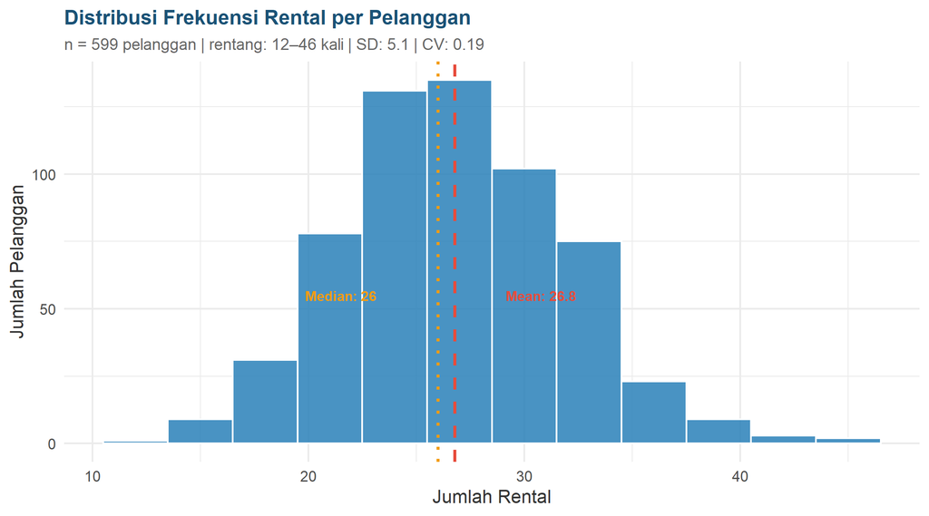

```r
rental_freq <- rental %>%
  group_by(customer_id) %>%
  summarise(jumlah_rental = n(), .groups = "drop")

rata2_freq <- mean(rental_freq$jumlah_rental)
med_freq   <- median(rental_freq$jumlah_rental)
sd_freq    <- sd(rental_freq$jumlah_rental)
cv_freq    <- sd_freq / rata2_freq

ggplot(rental_freq, aes(x = jumlah_rental)) +
  geom_histogram(binwidth = 3, fill = "#2980b9", color = "white", alpha = 0.85) +
  geom_vline(xintercept = rata2_freq, color = "#e74c3c",
             linetype = "dashed", linewidth = 1) +
  geom_vline(xintercept = med_freq, color = "#f39c12",
             linetype = "dotted", linewidth = 1) +
  annotate("text", x = rata2_freq + 4, y = 55,
           label = paste0("Mean: ", round(rata2_freq, 1)),
           color = "#e74c3c", size = 3.4, fontface = "bold") +
  annotate("text", x = med_freq - 4.5, y = 55,
           label = paste0("Median: ", round(med_freq, 1)),
           color = "#f39c12", size = 3.4, fontface = "bold") +
  labs(
    title    = "Distribusi Frekuensi Rental per Pelanggan",
    subtitle = sprintf("n = %d pelanggan | rentang: %d–%d kali | SD: %.1f | CV: %.2f",
                       nrow(rental_freq),
                       min(rental_freq$jumlah_rental),
                       max(rental_freq$jumlah_rental),
                       sd_freq, cv_freq),
    x = "Jumlah Rental", y = "Jumlah Pelanggan"
  )
```

Distribusi frekuensi rental berkisar antara **12** hingga **46** kali per pelanggan, dengan rata-rata 26.8 dan median 26. Standar deviasi sebesar 5.1 dan *coefficient of variation* (CV) 0.19 menunjukkan variasi yang moderat. Kedekatan nilai mean dan median mengindikasikan distribusi yang relatif simetris, tanpa dominasi ekstrem pada salah satu ujung distribusi.